# Algoritmo de Gibbs

Luis Miguel Calvo Magaz and Adrián Poncela Gómez

7 de marzo de 2019

## Introducción

Considera un modelo de regresión con efectos aleatorios para analizar los datos del ejemplo D (ratas.xls: contiene las observaciones del peso en 5 momentos del tiempo : 8,15,22,29 y 36 días). Considera que tanto el término independiente como el coeficiente de la variable explicativa (tiempo centrado $(x-\bar x)$) son a su vez variables aleatorias normales que dependen de hiperparámetros.

## Modelo en términos de los parámetros e hiperparámetros.

Modelo jerárquico normal:
$$y_{ij}\;=\; Peso\;de\;la\;rata\;i\;en\;el\;día\;x_j\;,\;i\in\{1,2,...,30\}\;,\;x_j\in\{8,15,22,29,36\}$$
$$x_j\;=\;Momento\;de\;tiempo\;j\;,\;j\in\{1,2,3,4,5\}\;,\;x_j\in\{8,15,22,29,36\}$$
$$y_{ij} \sim Normal(\alpha_i + \beta_i·(x_j-\bar{x}) ,\;\sigma_y^2)$$
donde:

$$\alpha_i \sim Normal(\mu_\alpha,\sigma_\alpha^2)$$
$$\beta_i \sim Normal(\mu_\beta,\sigma_\beta^2)$$

## Resumen de los datos

```
##        tiempo1 tiempo2 tiempo3 tiempo4 tiempo5
## rata1      151     199     246     283     320
## rata2      145     199     249     293     354
## rata3      147     214     263     312     328
## rata4      155     200     237     272     297
## rata5      135     188     230     280     323
## rata6      159     210     252     298     331
## rata7      141     189     231     275     305
## rata8      159     201     248     297     338
## rata9      177     236     285     350     376
## rata10     134     182     220     260     296
## rata11     160     208     261     313     352
## rata12     143     188     220     273     314
## rata13     154     200     244     289     325
## rata14     171     221     270     326     358
## rata15     163     216     242     281     312
## rata16     160     207     248     288     324
## rata17     142     187     234     280     316
## rata18     156     203     243     283     317
## rata19     157     212     259     307     336
## rata20     152     203     246     286     321
## rata21     154     205     253     298     334
## rata22     139     190     225     267     302
## rata23     146     191     229     272     302
## rata24     157     211     250     285     323
## rata25     132     185     237     286     331
## rata26     160     207     257     303     345
## rata27     169     216     261     295     333
## rata28     157     205     248     289     316
## rata29     137     180     219     258     291
## rata30     153     200     244     286     324
```

Medias:

```
##  tiempo1  tiempo2  tiempo3  tiempo4  tiempo5
## 152.1667 201.7667 245.0333 289.5000 324.8000
```

Varianzas:

```
##  tiempo1  tiempo2  tiempo3  tiempo4  tiempo5
## 124.6264 160.5989 236.2402 367.0172 378.6483
```

## Implementación del Modelo jerárquico en R:

### Funciones de las Distribuciones condicionadas de los parámetros

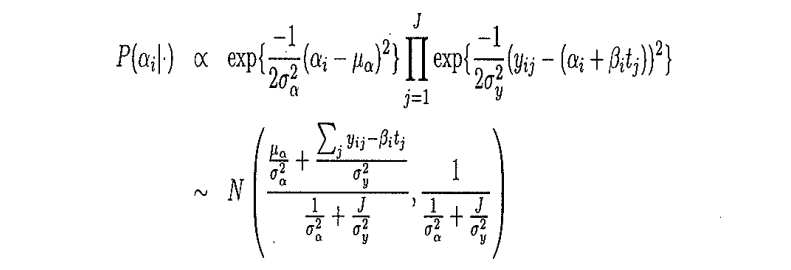

```r
alpha_condicionada <- function(mu_alpha,sigma2_alpha,peso,beta,tiempos){
  J <- length(peso)
  media <- 0
  varianza <- 0
  sumatorio <- 0
  for(j in 1:J){
      sumatorio <- sumatorio + (peso[j]-beta*tiempos[j])
  }
  media <- (mu_alpha/sigma2_alpha) + (sumatorio/((1/sigma2_alpha)+(J/sigma2_y)))
  varianza <- 1/((1/sigma2_alpha)+(J/sigma2_y))
  return(rnorm(1,media,sqrt(varianza)))
}
```

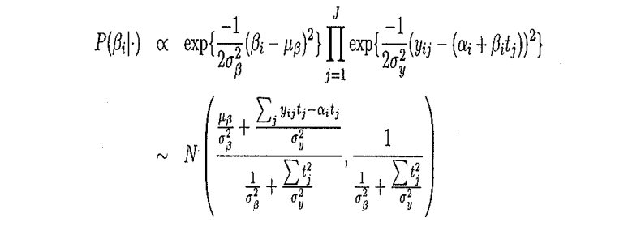

```r
beta_condicionada <- function(mu_beta,sigma2_beta,peso,alpha,tiempos){
  J <- length(peso)
  media <- 0
  varianza <- 0
  sumatorio <- 0
  for(j in 1:J){
    sumatorio <- sumatorio+(peso[j]*tiempos[j]-alpha*tiempos[j])
  }
  media <- ((mu_beta/sigma2_beta) + (sumatorio/sigma2_y))/((1/sigma2_beta)+(sum(tiempos^2)/sigma2_y))
  varianza <- 1/((1/sigma2_beta)+(sum(tiempos^2)/sigma2_y))
  return(rnorm(1,media,sqrt(varianza)))
}
```

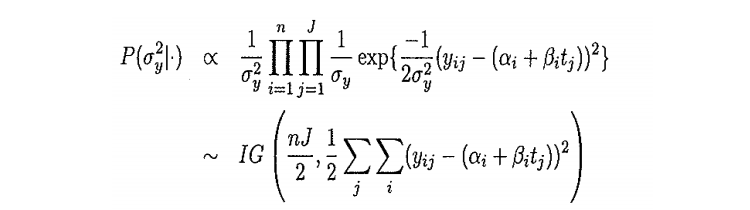

```r
sigma2_y_condicionada <- function(Y,alpha,beta,X){
  n <- dim(Y)[1]
  J <- dim(Y)[2]
  media <- n*J/2
  sumatorio <- 0.0
  for(j in 1:J){
    for(i in 1:n){
      sumatorio <- sumatorio + (Y[i,j] - (alpha[i] + beta[i]*X[j]))^2
    }
  }
  dispersion <- sumatorio/2
  gamma_inversa <- rigamma(n=1,alpha = media,beta = dispersion)
  return(gamma_inversa)
}
```

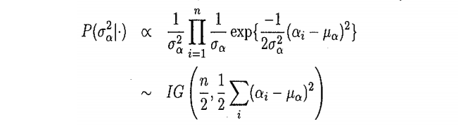

```r
sigma2_alpha_condicionada <- function(Y,alpha,mu_alpha){
  n <- dim(Y)[1]
  media <- n/2
  sumatorio <- 0
  for(i in 1:n){
    sumatorio <- sumatorio + (alpha[i] - mu_alpha)^2
  }
  dispersion <- sumatorio/2
  gamma_inversa <- rigamma(n=1,alpha=media,beta =dispersion)
  return(gamma_inversa)
}
```

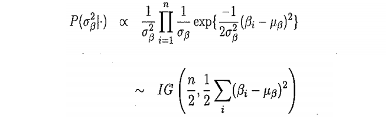

```r
sigma2_beta_condicionada <- function(Y,beta,mu_beta){
  n <- dim(Y)[1]
  media <- n/2
  sumatorio <- 0
  for(i in 1:n){
    sumatorio <- sumatorio + (beta[i] - mu_beta)^2
  }
  dispersion <- sumatorio/2
  gamma_inversa <- rigamma(n=1,alpha=media,beta =dispersion)
  return(gamma_inversa)
}
```

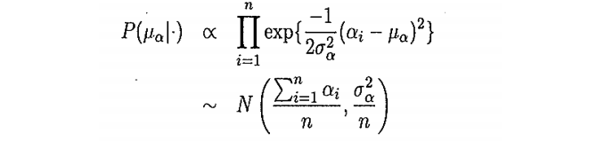

```r
mu_alpha_condicionada <- function(Y,alpha,sigma2_alpha){
  n <- dim(Y)[1]
  media <- sum(alpha)/n
  varianza <- sigma2_alpha/n
  return(rnorm(1,media,sqrt(varianza)))
}
```

[figure not shown]

```r
mu_beta_condicionada <- function(Y,beta,sigma2_beta){
  n <- dim(Y)[1]
  media <- sum(beta)/n
  varianza <- sigma2_beta/n
  return(rnorm(1,media,sqrt(varianza)))
}
```

### Implementación del algoritmo de Gibbs en R:

Buscamos el mayor nivel de actualización, por lo que actualizamos todos los parámetros en cada iteracción para cada una de las ratas.

```r
gibbs <- function(datos,tiempos,numero_iteraciones,alpha,beta,sigma2_y,sigma2_alpha,sigma2_beta,mu_alpha,mu_beta){
  numero_parametros<-length(alpha)+length(beta)+5
  parametros<-matrix(rep(0.00,numero_parametros*numero_iteraciones),c(numero_iteraciones,numero_parametros))
  colnames(parametros)<-c(paste0("alpha",1:30),paste0("beta",1:30),"sigma_2_y","sigma2_alpha","sigma2_betas","mu_alpha","mu_beta")
  parametros[1,] <- c(alpha,beta,sigma2_y,sigma2_alpha,sigma2_beta,mu_alpha,mu_beta)
  for(i in 1:numero_iteraciones){
    for(j in 1:length(alpha)){
      mu_alpha <- mu_alpha_condicionada(datos,alpha,sigma2_alpha)
      mu_beta <- mu_beta_condicionada(datos,beta,sigma2_beta)
      sigma2_y <- sigma2_y_condicionada(datos,alpha,beta,tiempos)
      sigma2_alpha <- sigma2_alpha_condicionada(datos,alpha,mu_alpha)
      sigma2_beta <- sigma2_beta_condicionada(datos,beta,mu_beta)
      alpha[j] <- alpha_condicionada(mu_alpha,sigma2_alpha,datos[j,],beta[j],tiempos)
      beta[j] <- beta_condicionada(mu_beta,sigma2_beta,datos[j,],alpha[j],tiempos)
    }
    parametros_nuevos <- c(alpha,beta,sigma2_y,sigma2_alpha,sigma2_beta,mu_alpha,mu_beta)
    parametros[i,] <- parametros_nuevos
  }
  return(parametros)
}
```

### Resultados:

Obtenemos los siguientes resultados para 500 iteraciones y quemando el $10\%$ de las primeras iteraciones, en un tiempo de ejecución de **5.4526529** segundos.

- El vector medio de $\alpha$ (El intercept) sería:

```
##   alpha1   alpha2   alpha3   alpha4   alpha5   alpha6   alpha7   alpha8
## 240.6983 248.9293 253.7137 233.1442 232.1558 250.9182 229.0856 249.5400
##   alpha9  alpha10  alpha11  alpha12  alpha13  alpha14  alpha15  alpha16
## 285.6864 219.3580 259.7127 228.5274 243.3141 270.1258 243.7446 246.3399
##  alpha17  alpha18  alpha19  alpha20  alpha21  alpha22  alpha23  alpha24
## 232.6846 241.3068 255.0920 242.5203 249.7152 225.5208 228.8985 246.1496
##  alpha25  alpha26  alpha27  alpha28  alpha29  alpha30
## 235.1306 255.3147 255.7258 243.9064 217.9189 242.3114
```

- El vector medio de $\beta$ , (La pendiente) sería:

```
##    beta1    beta2    beta3    beta4    beta5    beta6    beta7    beta8
## 6.028136 7.309306 6.570724 5.092071 6.684529 6.167676 5.916611 6.481839
##    beta9   beta10   beta11   beta12   beta13   beta14   beta15   beta16
## 7.307832 5.746291 6.980307 6.103108 6.155469 6.837889 5.195043 5.840633
##   beta17   beta18   beta19   beta20   beta21   beta22   beta23   beta24
## 6.303641 5.747281 6.467543 6.015044 6.467768 5.757181 5.614870 5.801615
##   beta25   beta26   beta27   beta28   beta29   beta30
## 7.119115 6.657103 5.818547 5.747734 5.519530 6.116364
```

- La desviación $\sigma_y^2$ sería:

```
## [1] 23.53821
```

#### Gráficas de convergencia de los parámetros en las iteraciones:

- **$\mu_\alpha$**:

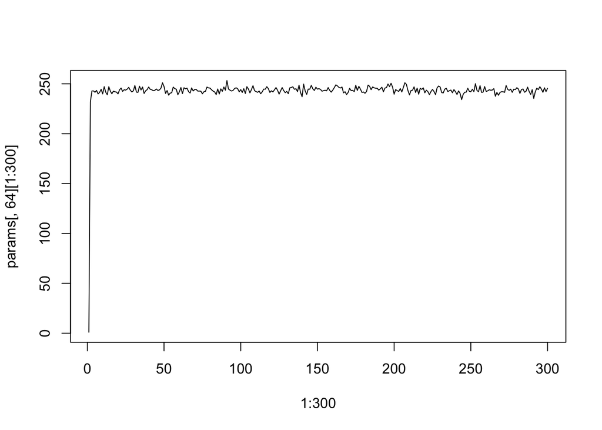

- **$\mu_\beta$**:

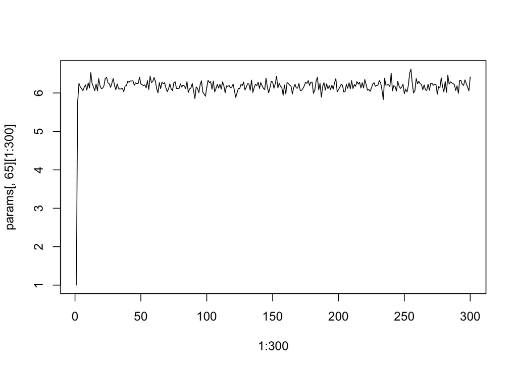

Podemos ver como rápidamente los parámetros convergen al resultado final sin necesidad de muchas iteraciones.

## Inferencias

### Inferencias sobe el parámetro del término independiente ($\alpha$):

Bandas de credibilidad del 95 % para alpha: Bandas de confianza para :
$$\alpha_i \sim Normal(\mu_\alpha,\sigma_\alpha^2),\;\;\;i = 1..30$$
Cuantiles de $\alpha_i$ 0.025 y 0.0975.
Podemos decir con una credibilidad del 95 % que los valores de $\alpha_i$ para cada una de las 30 ratas están entre:

```
##            2.5%    97.5%
## rata1  239.6974 241.7789
## rata2  248.0435 249.8981
## rata3  252.6772 254.7483
## rata4  232.0593 234.0661
## rata5  231.1703 233.0634
## rata6  249.9034 252.0042
## rata7  228.0897 230.1258
## rata8  248.5601 250.6351
## rata9  284.6382 286.9214
## rata10 218.3962 220.3242
## rata11 258.8240 260.6695
## rata12 227.5421 229.5408
## rata13 242.4332 244.4265
## rata14 269.1299 271.1553
## rata15 242.7703 244.7861
## rata16 245.4063 247.3527
## rata17 231.7683 233.7239
## rata18 240.3149 242.3429
## rata19 254.0500 256.0665
## rata20 241.4991 243.5707
## rata21 248.7915 250.7554
## rata22 224.5402 226.4566
## rata23 227.9675 229.7687
## rata24 245.1281 247.1023
## rata25 234.1655 236.1322
## rata26 254.3327 256.2520
## rata27 254.7533 256.6981
## rata28 242.9485 244.8577
## rata29 216.9321 218.8933
## rata30 241.4076 243.1638
```

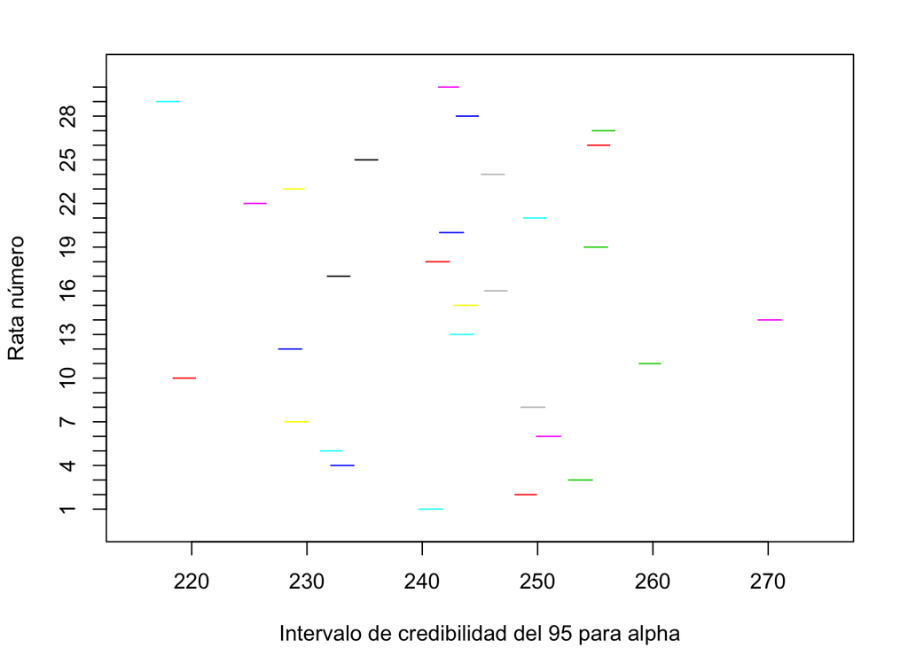

### Inferencias sobe el parámetro de la pendiente ($\beta$):

Bandas de credibilidad del 95 % para beta: Bandas de confianza para :
$$\beta_i \sim Normal(\mu_\beta,\sigma_\beta^2),\;\;\;i = 1..30$$
Cuantiles de $\beta_i$ 0.025 y 0.0975.
Podemos decir con una credibilidad del 95 % que los valores de $\beta_i$ para cada una de las 30 ratas están entre:

```
##            2.5%    97.5%
## rata1  5.939541 6.134252
## rata2  7.221906 7.393674
## rata3  6.482433 6.651157
## rata4  5.001291 5.179835
## rata5  6.601035 6.774085
## rata6  6.078582 6.252194
## rata7  5.837804 5.999914
## rata8  6.387347 6.561697
## rata9  7.219665 7.391997
## rata10 5.663057 5.825729
## rata11 6.895895 7.068748
## rata12 6.015309 6.181252
## rata13 6.059485 6.245233
## rata14 6.756852 6.918537
## rata15 5.106882 5.281519
## rata16 5.753191 5.927691
## rata17 6.223028 6.390745
## rata18 5.656395 5.837285
## rata19 6.378618 6.558554
## rata20 5.927708 6.101401
## rata21 6.378065 6.564830
## rata22 5.673639 5.839727
## rata23 5.526126 5.707314
## rata24 5.722087 5.886803
## rata25 7.025000 7.208937
## rata26 6.572400 6.745790
## rata27 5.728848 5.909316
## rata28 5.658865 5.831680
## rata29 5.436832 5.605942
## rata30 6.028034 6.200422
```

Un gráfico que puede representar esto sería:  
Donde se representa el Intervalo como una línea recta sólida horizontal para cada una de las ratas.

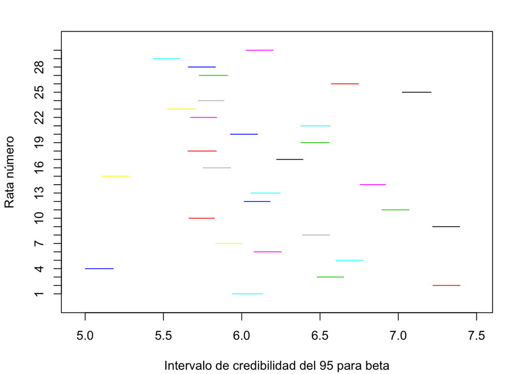